# Code for Calculating the Objective Functions

Daniel Klotz

12 Juli 2016

# 1 Introduction

This chapter defines the function necessary to calculate the objective functions $of$. The code for exploring and visualising objective function is defined in seperate sections:

- Explore Basin-Graphs with objective functions

Currently 4 objective functions are used in **visCOS**. They are calculated from the data columns of a data.frame defined by `viscos_options$name_data1` and `viscos_options$name_data2`. Assuming that `name_data1` is $x$ and `name_data1` is $y$ they are defined as shown in the following.

## 1.1 Nash-Sutcliffe Efficiency

The Nash-Sutcliffe Criterion $NSE$ is by far the most used efficiency criterion in hydrology. In the hydrological context $x$ usually represents a set of runoff-observation and $y$ a set of simulations. The $NSE$ is defined in the same way as the general definition of the coefficient of determination $R^2$:

$$NSE = \sum_{t=1}^T \frac{x(t)-y(t)}{x(t)-\bar{x}}.$$

The variable $\bar{x}$ represents the average of $x$. The $NSE$ can therefore be seen as the relational the estimator $y$ and the estimator resulting form the average of the data. The following figure illustrates different $NSE$ values for naive examples.

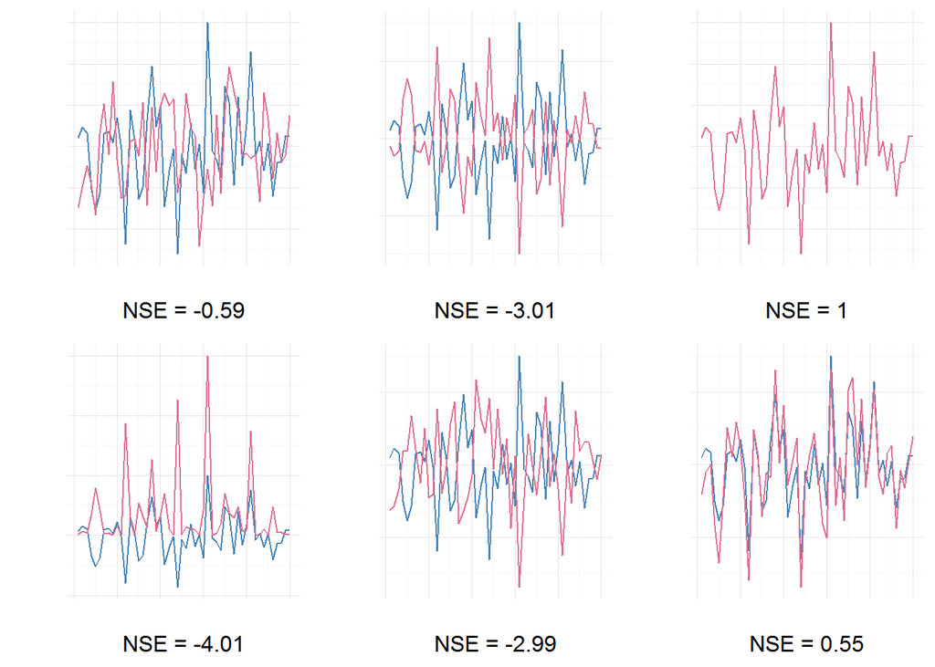

## 1.2 Kling-Gupta Efficiency

The Kling-Gupta Efficiency $KGE$ was introduced by Gupta et al. (2009) to alleviate some of the shortcomings of the $NSE$. In their paper they argue why the $NSE$ tends to overate simulations with small variance (note: in the context of the paper $\textrm{simulations} = y$) and propose the their efficiency criterion instead.

The $KGE$ is defined as:

$$KGE = 1 - ED,$$

with

$$ED = \sqrt{ (corr-1)^2 + (\alpha-1)^2 + (\beta-1)^2) };$$

Where $\alpha = \frac{\sigma_y}{ \sigma_x }$ , i.e.: standard deviation $\sigma$ of the $y$ divided by the $\sigma$ of $x$ and $\beta = \mu_y / \mu_x$ and $\mu$ is the arithmetic mean. The following figure exemplifies its usage for the same data as above.

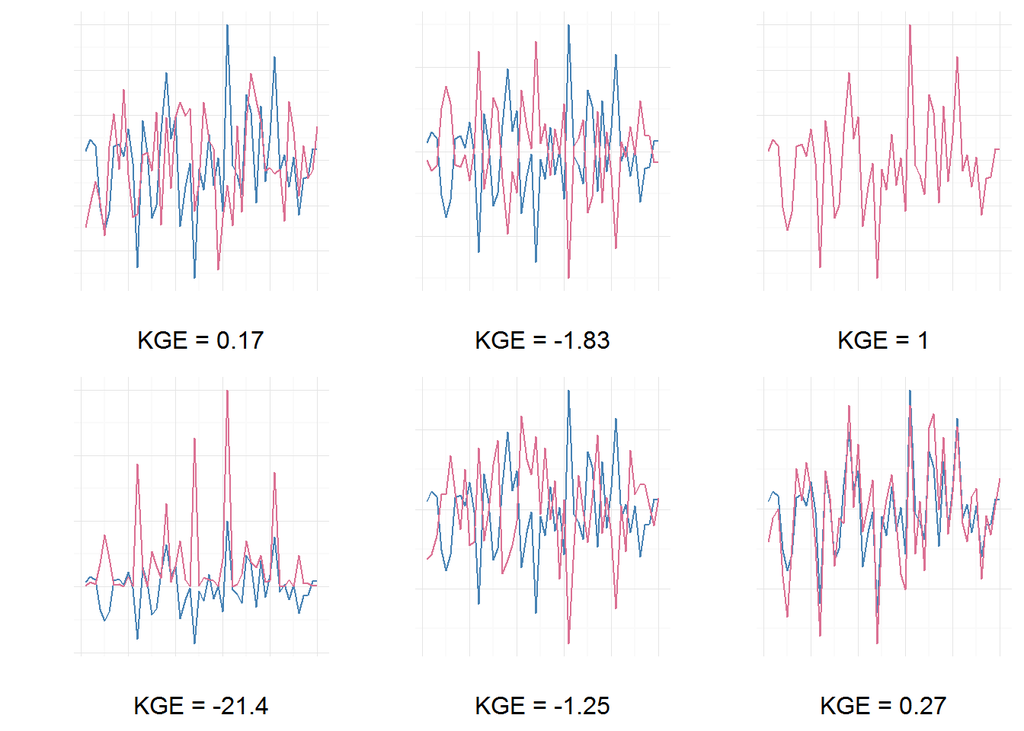

## 1.3 Percentage Bias

The percentage of bias $pBIAS$ is defined as the sum of the differences between $x$ and $y$ divided by the sum of $x$:

$$pBIAS = 100*\frac{\sum_{} [ x(t)-y(t) ] }{\sum_{} x(t)}.$$

The $100*$ is just a scaling factor applied to express $pBIAS$ as a percentage. The following figure illustrates different $pBIAS$ values for the same data as above.

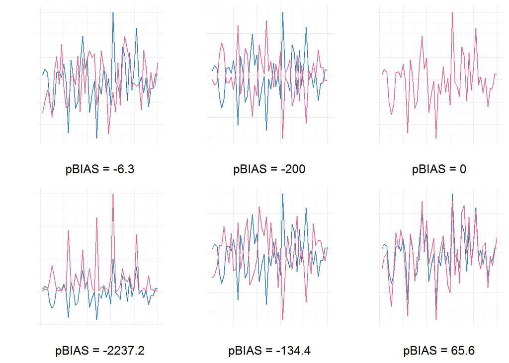

## 1.4 Pearson’s correlation coefficient

The correlation coefficient $corr$ is a measure of the linear relationship between $x$ and $y$. It is defined as:

$$corr = \frac{cov(x,y)}{\sigma^2_y*\sigma^2_x},$$

where $cov(...)$ denotes the covariance and $\sigma^2$ the variance. The correlation coefficient can take on values between -1 and 1. The former corresponds to a inverse and the latter to a direct relationship and the closer the values is to zero the weaker the implied correlation. The following figure taken from the illustrates some examples of $corr$ to give a feeling for its usage:

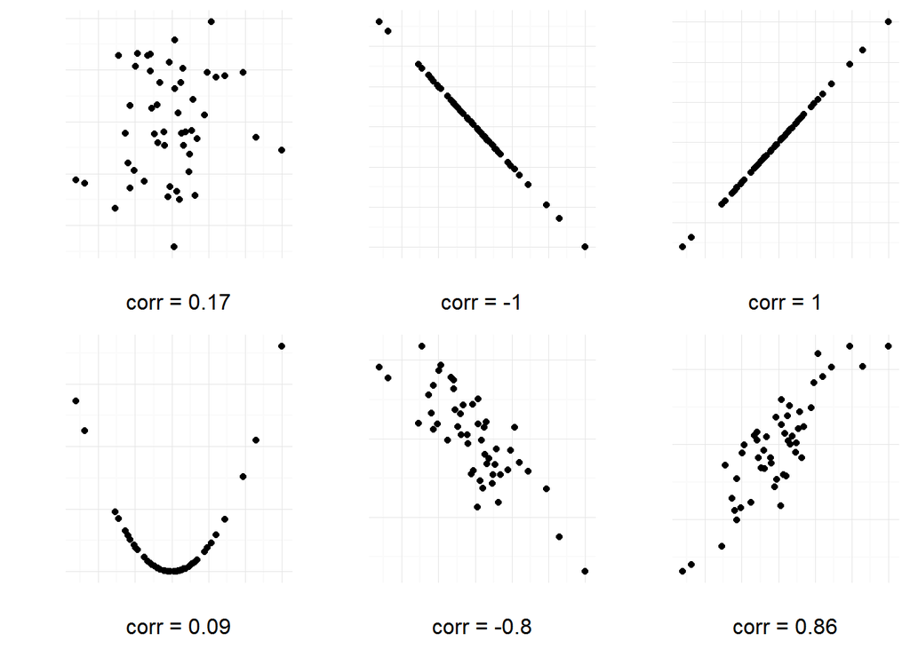

# 2 Code

## 2.1 `extract_objective_functions`

The purpose of this function is to extract a set of objective functions from the `runoff_data` data.frame. The objective functions are extracted for each basin, for the all the periods as a summary and for each period separately.

After the calculation of the `dplyr` is used to separate the different periods (see also `mark_periods`) and get access to the pipe operator `%>%`. As shown below the function checks if `runoff_data` is a data.frame and if the periods are marked before the real computation starts.

```r
#' Get basic objective function for runoff_data
#'
#' Calculate basic objective functions
#'(NSE, KGE, percentage BIAS, Correlation (see: xxx)) for
#' every basin and the chosen periods
#'
#' @param runoff_data runoff_data data.frame (see:xxx).
#' @return list of basic objective function evaluated for the different
#' hydrological years and over the whole timespan.
#' @export
extract_objective_functions <- function(runoff_data) {
  require("hydroGOF", quietly = TRUE)
  require("dplyr", quietly = TRUE)
  assert_dataframe(runoff_data)
  stopifnot( exists(viscos_options()$name_COSperiod, where = runoff_data) )
```

The computational part of the function works as follows. In step (I) the non-marked periods of `runoff_data` (i.e. columns of `viscos_options()$name_COSperiod` which are smaller then > 0) are excluded from further calculations. The thereby obtained data.frame is named `evaluation_data`. Then, step (II) extracts important information for the calculations:

- The number of basins (`number_of_basins`) is obtained by getting the names of the data.frame, applying `tolower` to make them independent of upper and lower cases and summing up all the name_data1 column,
- the indices of the marked periods (`periods_in_data`) are obtained by getting the unique values of the `viscos_options()$name_COSperiod` column, and
- number of periods (`number_of_periods`) are obtained by measuring the length of `periods_in_data`

```r
  # (I) reduce necessary computation
  evaluation_data <- runoff_data[
      runoff_data[[viscos_options()$name_COSperiod]] > 0,
    ]
  # (II) get information
  number_of_basins <- evaluation_data %>%
    names %>%
    unique %>%
    tolower %>%
    grepl(viscos_options()$name_data1 , .) %>%
    sum
  periods_in_data <- evaluation_data[[viscos_options()$name_COSperiod]] %>%
    unique
  number_of_periods <- periods_in_data %>% length
  # (III) calculate overall objective functions
  obj_fun  <- list()
  temp_x <- dplyr::select(evaluation_data,starts_with(viscos_options()$name_data1)) %>%
    unname
  temp_y <- dplyr::select(evaluation_data,starts_with(viscos_options()$name_data2)) %>%
    unname
  obj_fun$NSE <- hydroGOF::NSE(temp_y,temp_x)
  obj_fun$KGE <- hydroGOF::KGE(temp_y,temp_x)
  obj_fun$pBIAS <- hydroGOF::pbias(temp_y,temp_x)
  obj_fun$CORR <- cor(temp_y,temp_x) %>% diag(.)
  # (IV) calulcated period-vise objective functions
    # pre allocation of periodic variables:
    obj_fun$NSE_period <- matrix(nrow = number_of_periods, ncol = as.integer(number_of_basins), data = NA)
    obj_fun$KGE_period <- obj_fun$NSE_period
    obj_fun$pBIAS_periods <- obj_fun$NSE_period
    obj_fun$CORR_period <- obj_fun$NSE_period
    # calculation loop
    for (k in 1:number_of_periods)
    {
      temp_x <- dplyr::filter(evaluation_data,period == periods_in_data[k]) %>%
        dplyr::select(.,starts_with(viscos_options()$name_data1)) %>%
        unname
      temp_y <- dplyr::filter(evaluation_data,period == periods_in_data[k]) %>%
        dplyr::select(.,starts_with(viscos_options()$name_data2)) %>%
        unname
      obj_fun$NSE_period[k,1:number_of_basins] <- hydroGOF::NSE(temp_y,temp_x)
      obj_fun$KGE_period[k,1:number_of_basins] <- hydroGOF::KGE(temp_y,temp_x)
      obj_fun$pBIAS_period[k,1:number_of_basins] <- hydroGOF::pbias(temp_y,temp_x)
      obj_fun$CORR_period[k,1:number_of_basins] <- cor(temp_y,temp_x) %>% diag(.)
    }
  #
  return(obj_fun)
}
```

# 3 References

- Gupta, Hoshin V.; Kling, Harald; Yilmaz, Koray K. & Martinez, Guillermo F. (2009): *Decomposition of the mean squared error and NSE performance criteria:* *Implications for improving hydrological modelling* (Journal of Hydrology)